# EigenStuff

Study Notes:

Eigenvalues and Eigenvectors Problem Statement¶ Eigenvalues and eigenvectors¶

We learned from last chapter that matrix 𝐴 apply to column vector 𝑥, that is 𝐴𝑥, is a linear transformation of 𝑥. There is a special transform in the following form:

𝐴𝑥=𝜆𝑥 Where 𝐴 is 𝑛×𝑛 matrix, 𝑥 is 𝑛×1 column vector (𝑋≠0), and 𝜆 is some scalar. Any 𝜆 that satisfies the above equation is known as an eigenvalue of the matrix 𝐴, while the associated vector 𝑥 is called an eigenvector corresponding to 𝜆.

The motivation behind¶

The motivation behind the eigenvalues and eigenvectors is that, it helps us to understand the characteristics of the linear transformation, thus make things easy. We know that a vector 𝑥 can be transformed to a different vector by multiplying 𝐴 - 𝐴𝑥. The effect of the transformation represents a scale of the length of the vector and/or the rotate of the vector. The above equation points out that for some vectors, the effect of transformation of 𝐴𝑥 is only scale (stretching, compressing, and flipping). The eigenvectors are the vectors have this property and the eigenvalues 𝜆′𝑠 are the scale factors. Let’s look at the following example.

TRY IT Plot the vector 𝑥 = [[1], [1]] and the vector 𝑏=𝐴𝑥, where 𝐴 = [[2, 0], [0, 1]]

```python
import matplotlib.pyplot as plt
print(plt.style.available)
```

[output not shown]

```python
import numpy as np
import matplotlib.pyplot as plt

plt.style.use('seaborn-v0_8-notebook')

%matplotlib inline

def plot_vect(x, b, xlim, ylim):
    '''
    function to plot two vectors,
    x - the original vector
    b - the transformed vector
    xlim - the limit for x
    ylim - the limit for y
    '''
    plt.figure(figsize = (10, 6))
    plt.quiver(0,0,x[0],x[1],\
        color='k',angles='xy',\
        scale_units='xy',scale=1,\
        label='Original vector')
    plt.quiver(0,0,b[0],b[1],\
        color='g',angles='xy',\
        scale_units='xy',scale=1,\
        label ='Transformed vector')
    plt.xlim(xlim)
    plt.ylim(ylim)
    plt.xlabel('X')
    plt.ylabel('Y')
    plt.legend()
    plt.show()
```

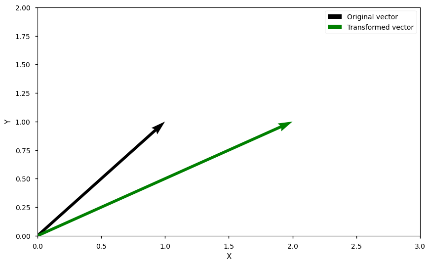

```python
A = np.array([[2, 0],[0, 1]])

x = np.array([[1],[1]])
b = np.dot(A, x)
plot_vect(x,b,(0,3),(0,2))
```

We can see from the generated figure that the original vector 𝑥 is rotated and stretched longer after transformed by 𝐴. The vector [[1], [1]] is transformed to [[2], [1]]. Let’s try to do the same exercise with a different vector [[1], [0]].

TRY IT! Plot the vector 𝑥 = [[1], [0]] and the vector 𝑏=𝐴𝑥, where 𝐴 = [[2, 0], [0, 1]]

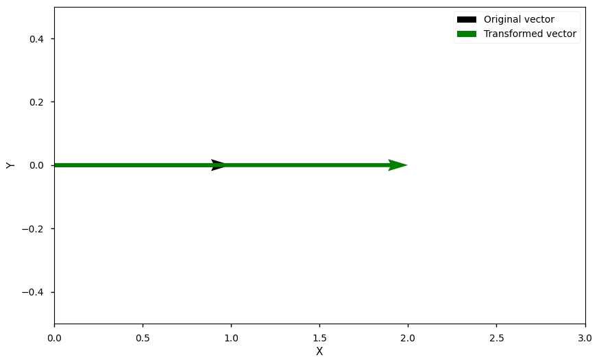

```python
x = np.array([[1], [0]])
b = np.dot(A, x)

plot_vect(x,b,(0,3),(-0.5,0.5))
```

Now we can see that with this new vector, the only thing changed after the transformation is the length of the vector, it is stretched. The new vector is [[2], [0]], therefore, the transform is

𝐴𝑥=2𝑥 with 𝑥 = [[1], [0]] and 𝜆=2. The direction of the vector doesn’t change at all (no rotation). You can also try that [[0], [1]] is another eigenvector, try to verify by yourself.

The characteristic equation¶

In order to get the eigenvalues and eigenvectors, from 𝐴𝑥=𝜆𝑥, we can get the following form:

(𝐴−𝜆𝐼)𝑥=0 Where 𝐼 is the identify matrix with the same dimensions as 𝐴. If matrix 𝐴−𝜆𝐼 has an inverse, then multiply both sides with (𝐴−𝜆𝐼)−1, we get a trivial solution 𝑥=0. Therefore, when 𝐴−𝜆𝐼 is singular (no inverse exist), we have a nontrivial solution, which means that the determinant is zero:

𝑑𝑒𝑡(𝐴−𝜆𝐼)=0 this equation is called characteristic equation, which will lead to a polynomial equation for 𝜆, then we can solve for the eigenvalues. Let’s look at one example.

TRY IT! Get the eigenvalues for matrix [[0, 2], [2, 3]]

The characteristic equation gives us

∣∣∣0−𝜆223−𝜆∣∣∣=0 Therefore, we have

−𝜆(3−𝜆)−4=0⇒𝜆2−3𝜆−4=0 We get two eigenvalues:

𝜆1=4,𝜆2=−1 TRY IT! Get the eigenvectors for the above two eigenvalues.

Let’s get the first eigenvector when 𝜆1=4, we can simply insert it back to 𝐴−𝜆𝐼=0, where we have:

[−422−1][𝑥1𝑥2]=[00] Therefore, we have two equations −4𝑥1+2𝑥2=0 and 2𝑥1−𝑥2=0, both of them indicate that 𝑥2=2𝑥1. Therefore, we can have the first eigenvector as

𝑥1=𝑘1[12] 𝑘1 is a scalar vector (𝑘1≠0), as long as we have the ratio between 𝑥2 and 𝑥1 as 2, it will be an eigenvector. We can verify the vector [[1], [2]] is an eigenvector by inserting it back:

[0223][12]=[48]=4[12] By inserting 𝜆2=−1 similarly as above, we can get the other eigenvector as the following, where 𝑘2≠0: $𝑥2=𝑘2[−21]$

From the above example, we can see how can we get the eigenvalues and eigenvectors from a matrix 𝐴, and the chosen of the eigenvectors for a system is not unique. But things will become really complicated when you have a larger matrix 𝐴 when you try to solve the 𝑛𝑡ℎ order polynomial characteristic equation. Luckily, there are many different numerical methods have been developed to solve the eigenvalue problems for larger matrices. We will introduce the power method and the QR method in the next two sections.

Find the largest eigenvalue¶

In some problems, we only need to find the largest dominant eigenvalue and its corresponding eigenvector. In this case, we can use the power method - a iterative method that will converge to the largest eigenvalue. Let’s see the following how the power method works.

Consider an 𝑛×𝑛 matrix 𝐴 that has 𝑛 linearly independent real eigenvalues 𝜆1,𝜆2,…,𝜆𝑛 and the corresponding eigenvectors 𝑣1,𝑣2,…,𝑣𝑛. Since the eigenvalues are scalars, we can rank them so that |𝜆1|>|𝜆2|>⋯>|𝜆𝑛| (actually, we only require |𝜆1|>|𝜆2|, other eigenvalues may be equal to each other).

Because the eigenvectors are independent, they are a set of basis vectors, which means that any vector that is in the same space can be written as a linear combination of the basis vectors. That is, for any vector 𝑥0, it can be written as:

𝑥0=𝑐1𝑣1+𝑐2𝑣2+⋯+𝑐𝑛𝑣𝑛

where 𝑐1≠0 is the constraint. If it is zero, then we need to choose another initial vector so that 𝑐1≠0.

Now let’s multiply both sides by 𝐴:

𝐴𝑥0=𝑐1𝐴𝑣1+𝑐2𝐴𝑣2+⋯+𝑐𝑛𝐴𝑣𝑛

Since 𝐴𝑣𝑖=𝜆𝑣𝑖, we will have:

𝐴𝑥0=𝑐1𝜆1𝑣1+𝑐2𝜆2𝑣2+⋯+𝑐𝑛𝜆𝑛𝑣𝑛

We can change the above equation to:

𝐴𝑥0=𝑐1𝜆1[𝑣1+𝑐2𝑐1𝜆2𝜆1𝑣2+⋯+𝑐𝑛𝑐1𝜆𝑛𝜆1𝑣𝑛]=𝑐1𝜆1𝑥1

where 𝑥1 is a new vector and 𝑥1=𝑣1+𝑐2𝑐1𝜆2𝜆1𝑣2+⋯+𝑐𝑛𝑐1𝜆𝑛𝜆1𝑣𝑛.

This finishes the first iteration. And we can multiply 𝐴 to 𝑥1 to start the 2nd iteration:

𝐴𝑥1=𝜆1𝑣1+𝑐2𝑐1𝜆22𝜆1𝑣2+⋯+𝑐𝑛𝑐1𝜆2𝑛𝜆1𝑣𝑛

Similarly, we can rearrange the above equation to:

𝐴𝑥1=𝜆1[𝑣1+𝑐2𝑐1𝜆22𝜆21𝑣2+⋯+𝑐𝑛𝑐1𝜆2𝑛𝜆21𝑣𝑛]=𝜆1𝑥2 where 𝑥2 is another new vector and 𝑥2=𝑣1+𝑐2𝑐1𝜆22𝜆21𝑣2+⋯+𝑐𝑛𝑐1𝜆2𝑛𝜆21𝑣𝑛.

We can continue multiply 𝐴 with the new vector we get from each iteration 𝑘 times:

𝐴𝑥𝑘−1=𝜆1[𝑣1+𝑐2𝑐1𝜆𝑘2𝜆𝑘1𝑣2+⋯+𝑐𝑛𝑐1𝜆𝑘𝑛𝜆𝑘1𝑣𝑛]=𝜆1𝑥𝑘 Because 𝜆1 is the largest eigenvalue, therefore, the ratio 𝜆𝑖𝜆1<1 for all 𝑖>1. Thus when we increase 𝑘 to sufficient large, the ratio of (𝜆𝑛𝜆1)𝑘 will be close to 0. So that all the terms that contain this ratio can be neglected as 𝑘 grows:

𝐴𝑥𝑘−1=𝜆1𝑣1 Essentially, as 𝑘 is large enough, we will get the largest eigenvalue and its corresponding eigenvector. When implementing this power method, we usually normalize the resulting vector in each iteration. This can be done by factoring out the largest element in the vector, which will make the largest element in the vector equal to 1. This normalization will get us the largest eigenvalue and its corresponding eigenvector at the same time. Let’s take a look of the following example.

You may ask when should we stop the iteration? The basic stopping criteria should be one of the three: in the consecutive iterations, (1) the difference between eigenvalues is less than some specified tolerance; (2) the angle between eigenvectors is smaller than a threshold ; or the norm of the residual vector is small enough.

```python
def normalize(x):
    fac = abs(x).max()
    x_n = x / x.max()
    return fac, x_n
```

```python
x = np.array([1, 1])
a = np.array([[0, 2],
              [2, 3]])

for i in range(8):
    x = np.dot(a, x)
    print('a=',a)
    print('x=',x)
    lambda_1, x = normalize(x)

print('Eigenvalue:', lambda_1)
print('Eigenvector:', x)
```

```
a= [[0 2]
 [2 3]]
x= [2 5]
a= [[0 2]
 [2 3]]
x= [2.  3.8]
a= [[0 2]
 [2 3]]
x= [2.         4.05263158]
a= [[0 2]
 [2 3]]
x= [2.         3.98701299]
a= [[0 2]
 [2 3]]
x= [2.         4.00325733]
a= [[0 2]
 [2 3]]
x= [2.         3.99918633]
a= [[0 2]
 [2 3]]
x= [2.         4.00020346]
a= [[0 2]
 [2 3]]
x= [2.         3.99994914]
Eigenvalue: 3.999949137887188
Eigenvector: [0.50000636 1.        ]
```

The inverse power method¶

The eigenvalues of the inverse matrix 𝐴−1 are the reciprocals of the eigenvalues of 𝐴. We can take advantage of this feature as well as the power method to get the smallest eigenvalue of 𝐴, this will be basis of the inverse power method. The steps are very simple, instead of multiplying 𝐴 as described above, we just multiply 𝐴−1 for our iteration to find the largest value of 1𝜆1, which will be the smallest value of the eigenvalues for 𝐴. As for the inverse of the matrix, in practice, we can use the methods we covered in the previous chapter to calculate it. We won’t got to the details here, but let’s see an example.

```python
from numpy.linalg import inv

print(a)

a_inv = inv(a)

print(a_inv)

for i in range(8):
    print(x)
    x = np.dot(a_inv, x)
    print(x)
    lambda_1, x = normalize(x)

print('Eigenvalue:', lambda_1)
print('Eigenvector:', x)
```

```
[[0 2]
 [2 3]]
[[-0.75  0.5 ]
 [ 0.5   0.  ]]
[0.50000636 1.        ]
[0.12499523 0.25000318]
[0.49997457 1.        ]
[0.12501907 0.24998728]
[0.50010173 1.        ]
[0.1249237  0.25005086]
[0.49959317 1.        ]
[0.12530513 0.24979658]
[0.50162866 1.        ]
[0.1237785  0.25081433]
[0.49350649 1.        ]
[0.12987013 0.24675325]
[0.52631579 1.        ]
[0.10526316 0.26315789]
[0.4 1. ]
[0.2 0.2]
Eigenvalue: 0.20000000000003912
Eigenvector: [1. 1.]
```

The shifted power method¶

In some cases, we need to find all the eigenvalues and eigenvectors instead of the largest and smallest. One simple but inefficient way is to use the shifted power method (we will introduce you an efficient way in next section). Given 𝐴𝑥=𝜆𝑥, and 𝜆1 is the largest eigenvalue obtained by the power method, then we can have:

[𝐴−𝜆1𝐼]𝑥=𝛼𝑥 where 𝛼’s are the eigenvalues of the shifted matrix 𝐴−𝜆1𝐼, which will be 0,𝜆2−𝜆1,𝜆3−𝜆1,…,𝜆𝑛−𝜆1.

Now if we apply the power method to the shifted matrix, then we can determine the largest eigenvalue of the shifted matrix, i.e. 𝛼𝑘. Since 𝛼𝑘=𝜆𝑘−𝜆1, we can get the eigenvalue 𝜆𝑘 easily. We can repeat this process many times to find the all the other eigenvalues. But you can see that, it involves a lot of work! A better method for finding all the eigenvalues is to use the QR method, let’s see the next section how it works!

The QR Method¶ The QR method is a preferred iterative method to find all the eigenvalues of a matrix (but not the eigenvectors at the same time). The idea is based on the following two concepts

similar matrices will have the same eigenvalues and associated eigenvectors. Two square matrices 𝐴 and 𝐵 are similar if: 𝐴=𝐶−1𝐵𝐶 where 𝐶 is an invertible matrix.

The QR method is a way to decompose a matrix into two matrices 𝑄 and 𝑅, where 𝑄 is an orthogonal matrix, and 𝑅 is an upper triangular matrix. An orthogonal matrix has the features: 𝑄−1=𝑄𝑇, which means 𝑄−1𝑄=𝑄𝑇𝑄=𝐼. How do we link these two concepts to find the eigenvalues? Say we have a matrix 𝐴0 whose eigenvalues must be determined. At the 𝑘-th step (starting with 𝑘=0), we can perform the QR decomposition and get 𝐴𝑘=𝑄𝑘𝑅𝑘, where 𝑄𝑘 is an orthogonal matrix and 𝑅𝑘 is an upper triangular matrix. We then form 𝐴𝑘+1=𝑅𝑘𝑄𝑘, which we note that

𝐴𝑘+1=𝑅𝑘𝑄𝑘=𝑄−1𝑘𝑄𝑘𝑅𝑘𝑄𝑘=𝑄−1𝑘𝐴𝑘𝑄𝑘 therefore, all the 𝐴𝑘 are similar, as we discussed above they all have the same eigenvalues.

```python
import numpy as np
from numpy.linalg import qr

a = np.array([[0, 2],
              [2, 3]])

q, r = qr(a)

print('Q:', q)
print('R:', r)

b = np.dot(q, r)
print('QR:', b)
```

```
Q: [[ 0. -1.]
 [-1.  0.]]
R: [[-2. -3.]
 [ 0. -2.]]
QR: [[0. 2.]
 [2. 3.]]
```

```python
a = np.array([[0, 2],
              [2, 3]])

p = [1, 5, 10, 20]

for i in range(20):
    q, r = qr(a)
    a = np.dot(r, q)
    if i+1 in p:
        print(f'Iteration {i+1}:')
        print(a)
```

```
Iteration 1:
[[3. 2.]
 [2. 0.]]
Iteration 5:
[[ 3.99998093  0.00976559]
 [ 0.00976559 -0.99998093]]
Iteration 10:
[[ 4.00000000e+00  9.53674316e-06]
 [ 9.53674316e-06 -1.00000000e+00]]
Iteration 20:
[[ 4.00000000e+00  9.09484250e-12]
 [ 9.09494702e-12 -1.00000000e+00]]
```

Though the methods we introduced so far look complicated, the actually calculation of the eigenvalues and eigenvectors in Python is fairly easy. The main built-in function in Python to solve the eigenvalue/eigenvector problem for a square array is the eig function in numpy.linalg. Let’s see how we can use it.

TRY IT Calculate the eigenvalues and eigenvectors for matrix 𝐴=[0223].

a = np.array([[0, 2], [2, 3]])

```python
import numpy as np
from numpy.linalg import eig
```

```python
a = np.array([[0, 2],
              [2, 3]])
w,v=eig(a)
print('E-value:', w)
print('E-vector', v)
```

```
E-value: [-1.  4.]
E-vector [[-0.89442719 -0.4472136 ]
 [ 0.4472136  -0.89442719]]
```

```python
a = np.array([[2, 2, 4],
              [1, 3, 5],
              [2, 3, 4]])
w,v=eig(a)
print('E-value:', w)
print('E-vector', v)
```

```
E-value: [ 8.80916362  0.92620912 -0.73537273]
E-vector [[-0.52799324 -0.77557092 -0.36272811]
 [-0.604391    0.62277013 -0.7103262 ]
 [-0.59660259 -0.10318482  0.60321224]]
```

Summary¶

Eigenvalues and eigenvectors help us to understand the characteristics of the linear transformation.

Eigenvectors of a matrix are the vectors that only be scaled length without rotation after the matrix transformation, the eigenvalues are the factors of the scale.

We can use power method to get the largest eigenvalue and corresponding eigenvector of a matrix.

The inverse power method can help us to get the smallest eigenvalue and corresponding eigenvector of a matrix.

The shifted power method can get all the other eigenvectors/eigenvectors of a matrix.

The preferred method to get all the eigenvalues is the QR method.